# Project 6 - Poverty and Education for Male and Females in Texas

Lehmann Jacob - Sanchez Luis - Minh-Tri Ho (mh47723) - Minh-Tuan Ho (mh47727)

April 24, 2017

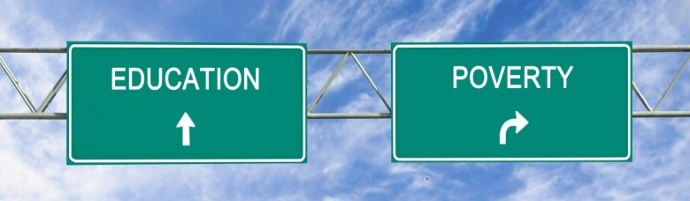

# **Introduction**

This is Project 6 of the course CS329e Elements of Data Visualization. This notebook includes every step that we took to build our project. In this project, we are going to look at the Education versus Poverty per County during the last Census Data, as well as Health Insurance per County, taking into account variables such as County Population, Poverty Ratings for 18-24 and 25-34 Males, Poverty Ratings for 18-24 and 25-34 Females, Number of Male having and not having Insurance being some of the examples.

# **The Data**

The data has been collected from the Census Data and uploaded to a private dataset [data.world](https://data.world/lordlemon/s-17-edvproject-6). The data consists of 3 tables. The first table is Education, which consists of 2117 rows and 6 columns for 12702 records. The rows describe Texas Counties, and the columns describe the County Name, the Population, the number of Male Undergraduates, Graduates, Female Undergraduates and Graduates. The second table represents Health Insurance, with 2117 rows and 4 columns, for 8468 records. The rows still describe Texas Counties, whereas columns describe the County Name, the Population, the number of Male with Health Insurance and the number of Male without Health Insurance. Finally, the last graph represent Poverty, with 2117 rows and 6 columns, for 12702 records. The rows still describe Texas Counties, and columns describe the County Name, the Population, the number of 18-24 Male in Poverty, the number of 25-34 Male in Poverty, the number of 18-24 Female in Poverty, and the number of 25-34 Female in Poverty.

The full dataset has a total of over 33,000 records.

# **Data Visualization #1: Tableau - Male Undergraduates versus Poverty in Texas cities**

## *Description*

The left graph represent the 30 counties with relatively high poverty levels. The right graph represents the education level of 18-24 Males in those same counties. The average of the poverty level is 12.9. The average of education level is 7.5. The two following graphs look at the 30 highest counties with high Education Levels. We are looking at the Poverty levels in those cities. Comparing them together, we would assume that cities with high poverty would have low Education levels, and cities with high Education levels would have low Poverty levels.

## *Graph*

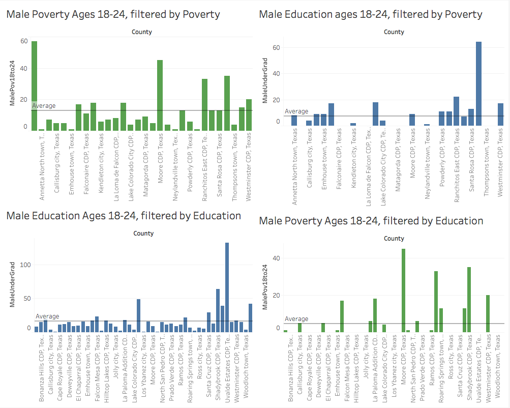

## *Interpretation*

We notice that cities with High Poverty Levels Average makes low Education, whereas High Education Counties have lower Poverty rates in average, showing a correlation between Poverty and lower Education Levels, which confirm our assumptions.

# **Data Visualization #2: Tableau - Female Undergraduates versus Poverty in Texas cities**

## *Description*

We are now trying to have the same visual representation of counties, for Females. We assume the same trends between Poverty and Education levels, where High Poverty would lead to Low Education, and High Education would lead to Low Poverty levels.

## *Graph*

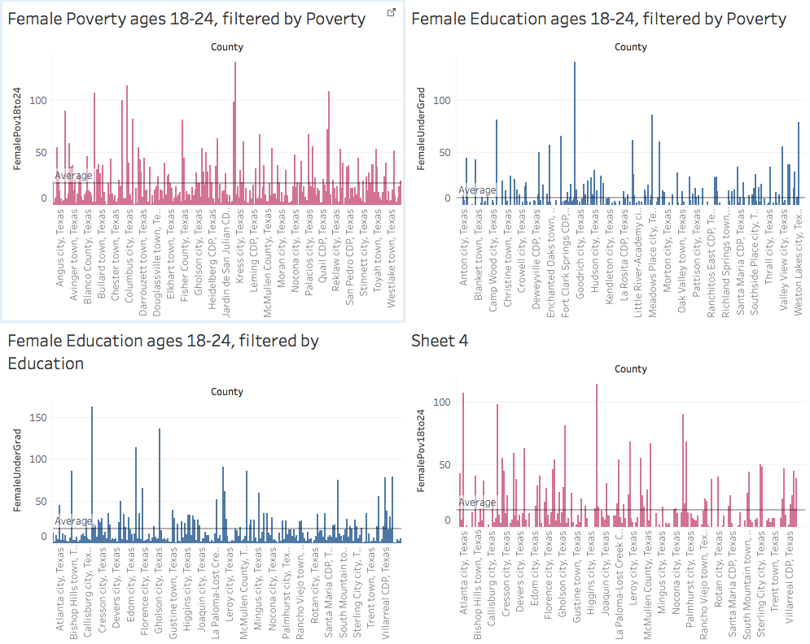

## *Interpretation*

High Poverty also shows lower Education levels. However, high Education levels counties still show high Poverty levels for Females. The correlation here only work one way, as Poverty is a predictor of lower education, but having higher Education doesn’t ensure lower Poverty levels.

# **Data Visualization #3: Tableau - Poverty versus Health Insurance for 18-24 Males in Texas cities**

## *Description*

This visualization tries to understand the relation between Poverty and Health Insurance. That implicitly measures the quality of Social Services to provide basic healthcare to poor people. We would assume that having high level of Poverty would induce lower Health Insurance coverage.

## *Graph*

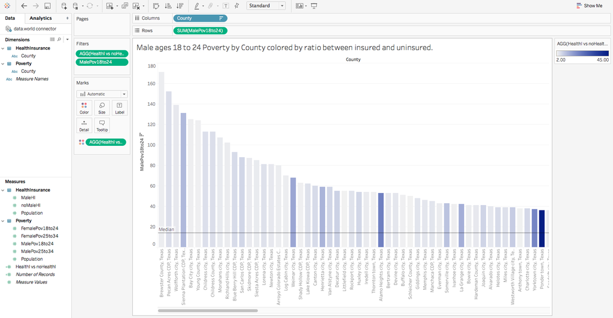

# **Shiny BarChart**

With this app hosted with Shinyapps, the barcharts for each visualization can be viewed through this link: https://leo16.shinyapps.io/project6/

# **Conclusion**

In conclusion, we would assume that poor people would still not have access to Education or Healthcare. However, we would hope that in a country as developped as the United States, and furthermore in a state as wealthy as Texas, that those social disparities would be less obvious. Unfortunately, those three visualizations show that poor people still have the same low access to Education and Health Insurance. On top of that, in case of female people, even having access to Education is not a predictor of wealth.